# Progress Report

Shusei Eshima

2018-04-15

```r
library(topicdict)
library(quanteda)
library(tibble)
library(ggplot2)
library(dplyr)
library(topicmodels)
```

# Read Data

```r
iter_num <- 500
folder <- paste0("/Users/Shusei/Dropbox/Study/My_Research/TreeStructuredTopicModel/Papers/replication/Catalinac/data/docs") # Data from original data Document-Term Matrix
docs <- list.files(folder, pattern = "*.txt", full.names = TRUE)
explore_ <- explore(docs,
             remove_numbers = TRUE,
             remove_punct = TRUE,
             remove_symbols = TRUE,
             remove_separators = TRUE)
```

Create model function

```r
create_model <- function(docs, seed_list, extra_k){
    set.seed(225)
    names(seed_list) <- 1:length(seed_list)
    dict <- quanteda::dictionary(seed_list)
  model <- topicdict_model(docs,
               dict = dict, extra_k = extra_k,
               remove_numbers = TRUE,
               remove_punct = TRUE,
               remove_symbols = TRUE,
               remove_separators = TRUE)

  return(model)
}
```

# About the original paper

## Selection of the number of topics

“After experimenting with specifications of between 20 and 200 topics, we settled on a speciﬁcation of 69 topics because it was one of the lowest specifications that appeared to produce topics that were ﬁne-grained enough to resemble our three quantities of interest.” (Appendix B, p.2)

## Topics the author uses to validate the result in the Appendix

### Party-platform topics

Topics that are primarily discussed by the candidates of a single party in a single election (Appendix C, p.3)

### Issue topics

Topics that are primarily discussed by candidates of more than one party in more than one election

## List of topics explained in Appendix

### Agriculture, Forestry, and Fisheries (Topic 52 in the original output)

Top words: agriculture, industry, manufacture, provide, carry out, fishing, akita (the name of prefecture), develop, push for, prefecture, merchant, yamagata (the name of prefecture), community, development, technology

### Worry About Earthquakes and Nuclear Power (Topic 62 in the original output)

Top words: fukui (the name of prefecture), shizuoka (the name of prefecture), recovery, coalition, kobe (the name of prefecture), gifu (the name of prefecture), economy, ruling party, prefecture, disaster victim, airport, industry, government, disaster, person

### Liberal Democracy is the Best (Topic 63 in the original output)

Top words: politic, ism, liberal, society, democracy, osaka (the name of prefecture), peace, realize, japan, human, aim for, rich, welfare, protect, person

### Consumption Tax is to Fund the Military (Topic 20 in the original output)

Top words: tax, politic, consumption, abolish, ldp, citizen, liberal, japan, protect, rice, business, import, realize, donation, block

### Benefits for Organized Groups (Topic 58 in the original paper)

Top words: business, education, small-medium, enrich, carry out, welfare, push for, better, stable, household, stimulate, measure,benefits, building, pension

## Particularistic topics and programmatic topics

The author reads manifestos (documents) with high probabilities of belonging to each topic and collects the groups of people candidates suggested would benefit from the promises associated with it. Next, the author calculates the proportion of each beneficiary in Japan’s population using official sources.

The author defines policies that purport to benefit large groups of voters as “programmatic” and policies that purport to benefit small groups of voters as “particularistic”. Calculation of the percentage of Japan’s population each topic purports to benefit allows the author to use topic’s largest beneficiary to classify topics into particularistic and programmatic.

## Seeds List

```r
# Top fifteen words appeared in the original output
topic52 <- c("農業 産業 工業 整備 図る 漁業 秋田 開発 進める 県 商 山形 地域 発展 技術")
topic62 <- c("福井 静岡 復興 連立 神戸 岐阜 経済 与党 県 被災 空港 産業 政権 災害 ひと")
topic63 <- c("政治 主義 自由 社会 民主 大阪 平和 実現 日本 人間 目指す 豊か 福祉 守る ひと")
topic20 <- c("税 政治 消費 廃止 自民党 国民 自由 日本 守る コメ 企業 輸入 実現 献金 阻止")
topic58 <- c("企業 教育 中小 充実 図る 福祉 進める 改善 安定 家庭 振興 対策 恩給 作り 年金")

seed_list <- list(topic52, topic62, topic63, topic20, topic58)
```

# Explore Data

```r
# Use a part of seed words
use_part_of_seed <- function(x, use=1:5){
    words <- strsplit(x, " ")[[1]][use] # use part of seed
    res <- paste(words, collapse=" ") # back to seed_list format
    return(res)
}


# Top words
explore_$top_words(n=10)
```

```
# A tibble: 10 x 4
    Word WordCount `Proportion(%)` Ranking
   <chr>     <dbl>           <dbl>   <int>
 1  政治     30828           2.290       1
 2  日本     19823           1.473       2
 3  社会     17403           1.293       3
 4  改革     14845           1.103       4
 5  国民     13913           1.034       5
 6    党     12544           0.932       6
 7  実現     11020           0.819       7
 8    税     10516           0.781       8
 9  教育      9908           0.736       9
10  守る      8681           0.645      10
```

```r
    # politics, japan, society, reform, people, party, realize, tax, education, defend

# Proportion
p <- explore_$visualize_dict_prop(seed_list)
ggsave(paste0(savepath, "Xseeds_all.pdf"), p, family="Japan1GothicBBB")

p <- explore_$visualize_dict_prop(lapply(seed_list, use_part_of_seed, use=1:8))
ggsave(paste0(savepath, "Xseeds_1-8.pdf"), p, family="Japan1GothicBBB")
```

# Fit Seeded LDA

## K+1 rule with different number of keywords

```r
model <- create_model(docs, seed_list, extra_k=1)
res <- topicdict_train(model, iter = iter_num, eta_1_regular=2)
post <- topicdict::posterior(res)
top_terms(post)
```

```
      1          2          3          4            5          T_1
 [1,] "整備 [✓]" "改革"     "政治 [✓]" "党"         "社会 [3]" "円"
 [2,] "推進"     "地方"     "社会 [✓]" "日本 [3]"   "教育 [✓]" "年金 [5]"
 [3,] "図る [✓]" "国"       "日本 [✓]" "政治 [3]"   "安心"     "制度"
 [4,] "産業 [✓]" "行政"     "実現 [✓]" "国民 [✓]"   "環境"     "政権 [2]"
 [5,] "作り [5]" "経済 [✓]" "国民 [4]" "税 [✓]"     "制度"     "医療"
 [6,] "振興 [5]" "国民 [4]" "改革"     "消費 [✓]"   "地域 [1]" "兆"
 [7,] "地域 [✓]" "日本 [3]" "生活"     "共産"       "実現 [3]" "廃止 [4]"
 [8,] "対策 [5]" "ひと [✓]" "福祉 [✓]" "自民党 [✓]" "年金 [✓]" "無駄"
 [9,] "充実 [5]" "政策"     "新しい"   "守る [3]"   "雇用"     "郵政"
[10,] "県 [✓]"   "議員"     "環境"     "憲法"       "医療"     "ひと [2]"
```

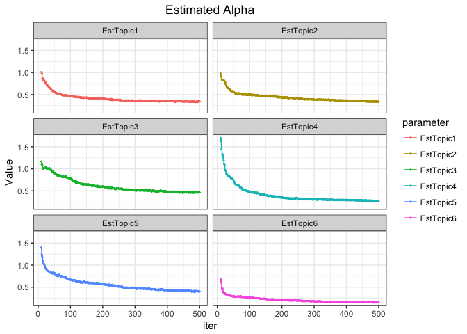

```r
diagnosis_alpha(post, start=10)
```

```r
tail(post$alpha,1)
```

```
    EstTopic1 EstTopic2 EstTopic3 EstTopic4 EstTopic5 EstTopic6 iter
500 0.3510521 0.3413047 0.4645573 0.2644347 0.4036062 0.1595968  500
```

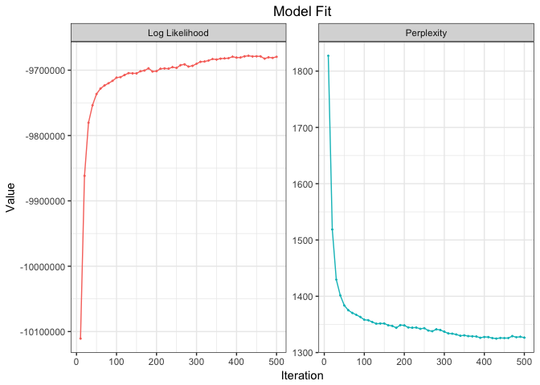

```r
diagnosis_model_fit(post, start=2)
```

Change eta

```r
model <- create_model(docs, seed_list, extra_k=1)
res <- topicdict_train(model, iter = iter_num, eta_1_regular=5)
post <- topicdict::posterior(res)
top_terms(post)
```

```
      1          2          3          4            5          T_1
 [1,] "整備 [✓]" "改革"     "政治 [✓]" "党"         "社会 [3]" "円"
 [2,] "推進"     "日本 [3]" "日本 [✓]" "日本 [3]"   "教育 [✓]" "年金 [5]"
 [3,] "図る [✓]" "地方"     "社会 [✓]" "国民 [✓]"   "安心"     "政権 [2]"
 [4,] "産業 [✓]" "国"       "国民 [4]" "政治 [3]"   "環境"     "制度"
 [5,] "振興 [5]" "経済 [✓]" "改革"     "税 [✓]"     "制度"     "医療"
 [6,] "作り [5]" "行政"     "実現 [✓]" "共産"       "医療"     "兆"
 [7,] "豊か [3]" "社会 [3]" "平和 [✓]" "消費 [✓]"   "地域 [1]" "廃止 [4]"
 [8,] "地域 [✓]" "政策"     "税 [4]"   "守る [3]"   "実現 [3]" "無駄"
 [9,] "郷土"     "国民 [4]" "選挙"     "自民党 [✓]" "年金 [✓]" "郵政"
[10,] "県 [✓]"   "問題"     "生活"     "憲法"       "雇用"     "民営"
```

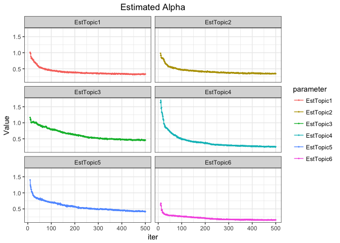

```r
diagnosis_alpha(post, start=10)
```

```r
tail(post$alpha,1)
```

```
    EstTopic1 EstTopic2 EstTopic3 EstTopic4 EstTopic5 EstTopic6 iter
500 0.3345271 0.3453897 0.4600635 0.2535897 0.4191726 0.1568705  500
```

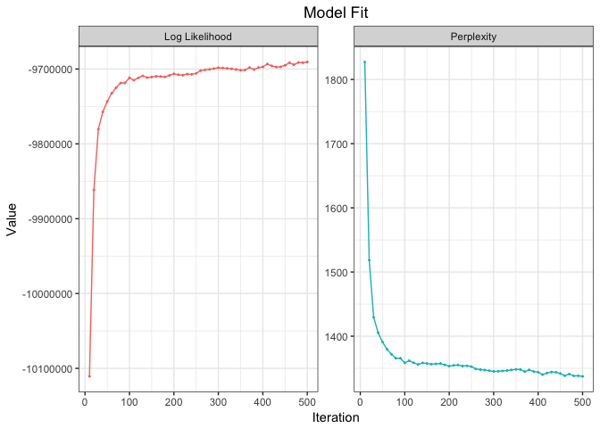

```r
diagnosis_model_fit(post, start=2)
```

```r
model <- create_model(docs, seed_list, extra_k=1)
res <- topicdict_train(model, iter = iter_num, eta_1_regular=8)
post <- topicdict::posterior(res)
top_terms(post)
```

```
      1          2          3          4            5          T_1
 [1,] "整備 [✓]" "改革"     "政治 [✓]" "党"         "社会 [3]" "円"
 [2,] "推進"     "日本 [3]" "日本 [✓]" "日本 [3]"   "教育 [✓]" "年金 [5]"
 [3,] "産業 [✓]" "地方"     "社会 [✓]" "税 [✓]"     "環境"     "政権 [2]"
 [4,] "図る [✓]" "国"       "国民 [4]" "政治 [3]"   "安心"     "制度"
 [5,] "振興 [5]" "経済 [✓]" "改革"     "国民 [✓]"   "実現 [3]" "医療"
 [6,] "地域 [✓]" "地域 [1]" "実現 [✓]" "消費 [✓]"   "制度"     "兆"
 [7,] "作り [5]" "行政"     "選挙"     "共産"       "年金 [✓]" "廃止 [4]"
 [8,] "豊か [3]" "政策"     "新しい"   "自民党 [✓]" "中小 [✓]" "無駄"
 [9,] "郷土"     "ひと [✓]" "生活"     "守る [3]"   "医療"     "郵政"
[10,] "県 [✓]"   "問題"     "自由 [✓]" "憲法"       "対策 [✓]" "民営"
```

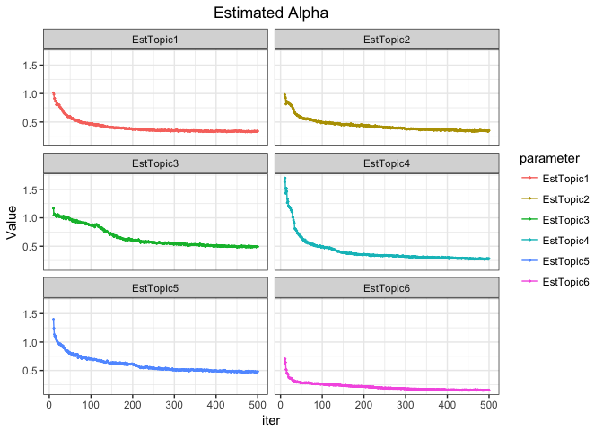

```r
diagnosis_alpha(post, start=10)
```

```r
tail(post$alpha,1)
```

```
    EstTopic1 EstTopic2 EstTopic3 EstTopic4 EstTopic5 EstTopic6 iter
500 0.3390188 0.3512306 0.4919608 0.2836424 0.4822811 0.1544577  500
```

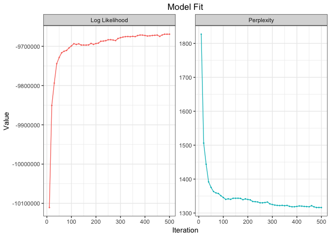

```r
diagnosis_model_fit(post, start=2)
```

## K+1 rule with five keywords

```r
model <- create_model(docs, lapply(seed_list, use_part_of_seed, use=1:5), extra_k=1)
res <- topicdict_train(model, iter = iter_num, eta_1_regular=2)
post <- topicdict::posterior(res)
top_terms(post)
```

```
      1          2          3            4          5
 [1,] "整備 [✓]" "円"       "政治 [✓]"   "党"       "税 [4]"
 [2,] "社会 [3]" "年金"     "改革"       "日本"     "消費 [4]"
 [3,] "図る [✓]" "制度"     "日本"       "政治 [3]" "円"
 [4,] "推進"     "政権"     "国民"       "国民"     "平和"
 [5,] "作り"     "医療"     "選挙"       "共産"     "国民"
 [6,] "地域"     "兆"       "社会 [✓]"   "増税"     "守る"
 [7,] "教育 [5]" "郵政"     "新しい"     "税 [✓]"   "廃止 [4]"
 [8,] "振興"     "無駄"     "自民党 [4]" "消費 [✓]" "実現"
 [9,] "豊か"     "廃止 [4]" "ひと"       "憲法"     "福祉"
[10,] "実現"     "民営"     "実現"       "守る"     "自民党 [4]"
      T_1
 [1,] "社会 [3]"
 [2,] "改革"
 [3,] "日本"
 [4,] "教育 [5]"
 [5,] "安心"
 [6,] "環境"
 [7,] "地域"
 [8,] "制度"
 [9,] "国"
[10,] "地方"
```

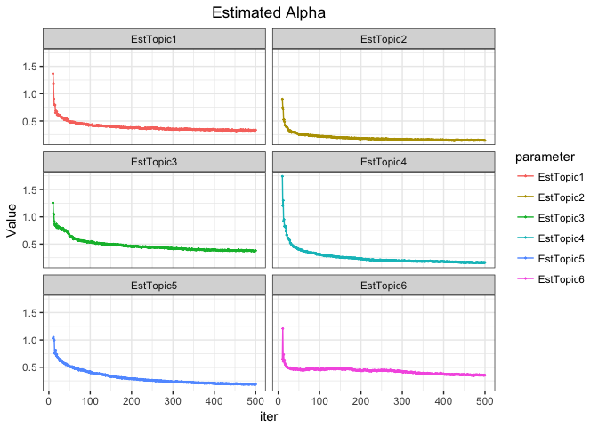

```r
diagnosis_alpha(post, start=10)
```

```r
tail(post$alpha,1)
```

```
    EstTopic1 EstTopic2 EstTopic3 EstTopic4 EstTopic5 EstTopic6 iter
500 0.3344597 0.1423664 0.3791635 0.1646521 0.1878328 0.3533506  500
```

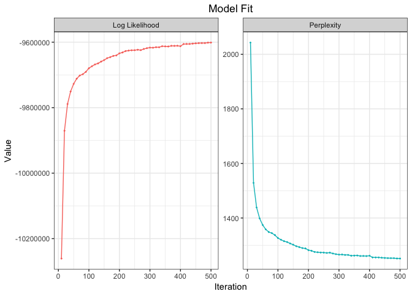

```r
diagnosis_model_fit(post, start=2)
```

```r
model <- create_model(docs, lapply(seed_list, use_part_of_seed, use=1:5), extra_k=1)
res <- topicdict_train(model, iter = iter_num, eta_1_regular=5)
post <- topicdict::posterior(res)
top_terms(post)
```

```
      1          2          3          4          5            T_1
 [1,] "整備 [✓]" "円"       "政治 [✓]" "党"       "税 [4]"     "社会 [3]"
 [2,] "図る [✓]" "年金"     "改革"     "日本"     "消費 [4]"   "改革"
 [3,] "社会 [3]" "制度"     "日本"     "政治 [3]" "平和"       "日本"
 [4,] "推進"     "医療"     "国民"     "国民"     "廃止 [4]"   "教育 [5]"
 [5,] "教育 [5]" "政権"     "社会 [✓]" "共産"     "自民党 [4]" "安心"
 [6,] "作り"     "兆"       "選挙"     "増税"     "国民"       "地域"
 [7,] "地域"     "郵政"     "新しい"   "税 [✓]"   "守る"       "環境"
 [8,] "実現"     "無駄"     "党"       "消費 [✓]" "福祉"       "地方"
 [9,] "充実 [5]" "廃止 [4]" "ひと"     "憲法"     "円"         "制度"
[10,] "振興"     "民営"     "実現"     "守る"     "実現"       "国"
```

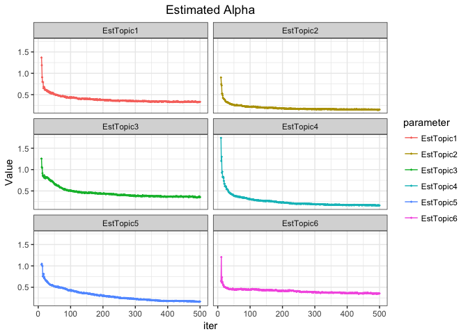

```r
diagnosis_alpha(post, start=10)
```

```r
tail(post$alpha,1)
```

```
    EstTopic1 EstTopic2 EstTopic3 EstTopic4 EstTopic5 EstTopic6 iter
500 0.3319644 0.1487284 0.3574507 0.1623847 0.1649007 0.3532602  500
```

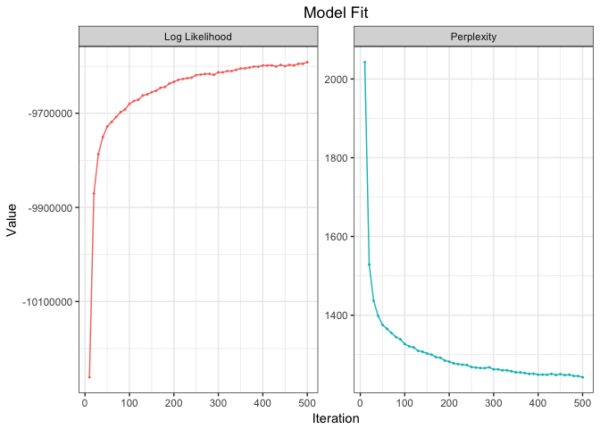

```r
diagnosis_model_fit(post, start=8)
```

## K+1 rule with eight keywords

```r
model <- create_model(docs, lapply(seed_list, use_part_of_seed, use=1:8), extra_k=1)
res <- topicdict_train(model, iter = iter_num, eta_1_regular=2)
post <- topicdict::posterior(res)
top_terms(post)
```

```
      1          2          3            4          5          T_1
 [1,] "整備 [✓]" "改革"     "政治 [✓]"   "党"       "教育 [✓]" "円"
 [2,] "社会 [3]" "日本 [4]" "国民 [4]"   "日本 [✓]" "社会 [3]" "年金"
 [3,] "推進"     "社会 [3]" "選挙"       "国民 [✓]" "実現 [3]" "政権"
 [4,] "地域"     "政治 [3]" "改革"       "政治 [3]" "年金"     "制度"
 [5,] "作り"     "地方"     "自民党 [4]" "共産"     "制度"     "医療"
 [6,] "図る [✓]" "国"       "実現 [✓]"   "税 [✓]"   "守る"     "郵政"
 [7,] "振興"     "地域"     "税 [4]"     "消費 [✓]" "医療"     "兆"
 [8,] "教育 [5]" "経済 [✓]" "党"         "増税"     "雇用"     "実現 [3]"
 [9,] "豊か"     "政策"     "消費 [4]"   "憲法"     "福祉 [✓]" "廃止 [4]"
[10,] "産業 [✓]" "行政"     "自由 [✓]"   "守る"     "充実 [✓]" "無駄"
```

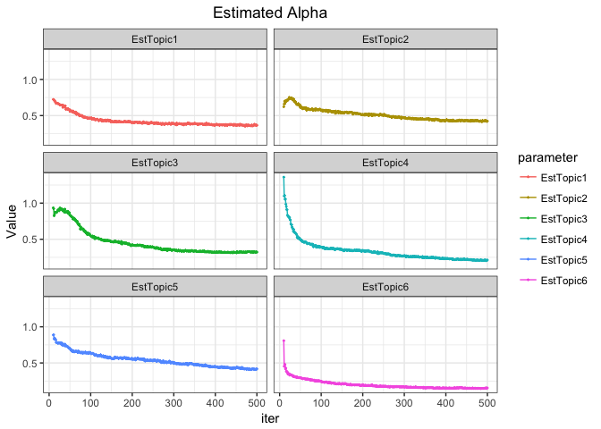

```r
diagnosis_alpha(post, start=10)
```

```r
tail(post$alpha,1)
```

```
    EstTopic1 EstTopic2 EstTopic3 EstTopic4 EstTopic5 EstTopic6 iter
500 0.3666607 0.4238048 0.3230859 0.2123498 0.4165502 0.1545027  500
```

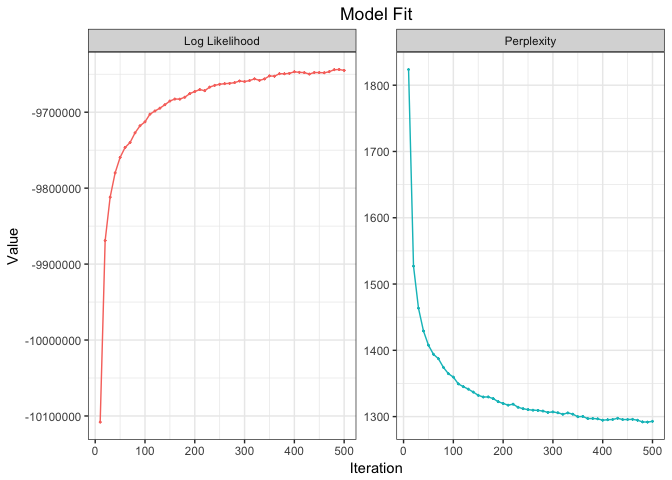

```r
diagnosis_model_fit(post, start=2)
```

```r
model <- create_model(docs, lapply(seed_list, use_part_of_seed, use=1:8), extra_k=1)
res <- topicdict_train(model, iter = iter_num, eta_1_regular=5)
post <- topicdict::posterior(res)
top_terms(post)
```

```
      1          2          3            4          5          T_1
 [1,] "整備 [✓]" "改革"     "政治 [✓]"   "党"       "社会 [3]" "年金"
 [2,] "推進"     "日本 [4]" "国民 [4]"   "日本 [✓]" "教育 [✓]" "円"
 [3,] "政治 [3]" "社会 [3]" "改革"       "国民 [✓]" "中小 [✓]" "制度"
 [4,] "作り"     "地方"     "選挙"       "政治 [3]" "年金"     "政権"
 [5,] "地域"     "国"       "自民党 [4]" "共産"     "守る"     "医療"
 [6,] "豊か"     "経済 [✓]" "社会 [✓]"   "税 [✓]"   "実現 [3]" "兆"
 [7,] "図る [✓]" "政治 [3]" "税 [4]"     "消費 [✓]" "福祉 [✓]" "郵政"
 [8,] "振興"     "地域"     "消費 [4]"   "増税"     "子供"     "無駄"
 [9,] "産業 [✓]" "政策"     "実現 [✓]"   "憲法"     "医療"     "廃止 [4]"
[10,] "発展"     "環境"     "党"         "守る"     "制度"     "民営"
```

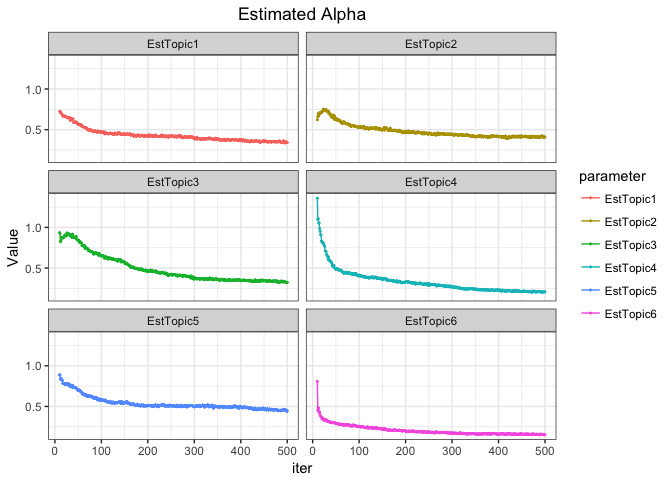

```r
diagnosis_alpha(post, start=10)
```

```r
tail(post$alpha,1)
```

```
    EstTopic1 EstTopic2 EstTopic3 EstTopic4 EstTopic5 EstTopic6 iter
500 0.3411709 0.4097336 0.3250698 0.2049975 0.4472485 0.1512286  500
```

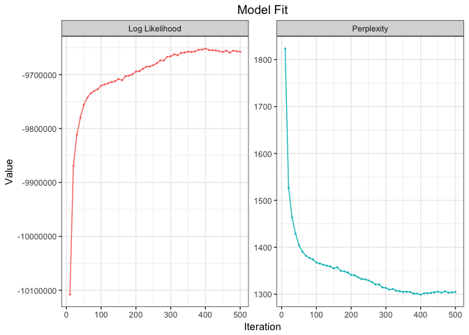

```r
diagnosis_model_fit(post, start=8)
```

# Increase the number of topics

## Same as the original

### With five keywords

```r
model <- create_model(docs, lapply(seed_list, use_part_of_seed, use=1:5), extra_k=64)
res <- topicdict_train(model, iter = iter_num)
post <- topicdict::posterior(res)
top_terms(post)
```

```
      1          2          3          4            5          T_1
 [1,] "整備 [✓]" "年金"     "社会 [✓]" "消費 [✓]"   "企業 [✓]" "政治 [3]"
 [2,] "産業 [✓]" "円"       "主義 [✓]" "税 [✓]"     "中小 [✓]" "声"
 [3,] "振興"     "改革"     "政治 [✓]" "政治 [3]"   "図る [1]" "国政"
 [4,] "道路"     "兆"       "自由 [✓]" "廃止 [✓]"   "教育 [✓]" "地域"
 [5,] "図る [✓]" "廃止 [4]" "民主 [✓]" "自民党 [✓]" "充実 [✓]" "いかす"
 [6,] "道"       "政権"     "経済"     "国民"       "進める"   "国会"
 [7,] "県"       "復興 [✓]" "守る"     "日本"       "制度"     "経験"
 [8,] "地域"     "実現"     "日本"     "自由 [3]"   "対策"     "県"
 [9,] "農林"     "増税"     "国民"     "党"         "まち"     "地元"
[10,] "交通"     "削減"     "実現"     "選挙"       "守る"     "秋田"
      T_2      T_3        T_4        T_5        T_6          T_7
 [1,] "保育"   "日本"     "社会 [3]" "農業 [1]" "政治 [3]"   "円"
 [2,] "支援"   "政治 [3]" "豊か"     "自給"     "政権"       "税 [4]"
 [3,] "ゼ"     "世界"     "作り"     "食糧"     "自民党 [4]" "消費 [4]"
```

[output cut: 117 more lines]

```r
tail(post$alpha,1)
```

```
    EstTopic1  EstTopic2 EstTopic3 EstTopic4 EstTopic5  EstTopic6
500 0.1756988 0.03219336 0.1039424 0.1060718 0.1868029 0.07774188
    EstTopic7 EstTopic8 EstTopic9 EstTopic10 EstTopic11 EstTopic12
500 0.0482269 0.1275899 0.1338563   0.083976 0.07798712 0.02327329
    EstTopic13 EstTopic14 EstTopic15 EstTopic16 EstTopic17 EstTopic18
500 0.05787314 0.09148959   0.122673 0.01661641  0.1056451 0.02834618
    EstTopic19 EstTopic20 EstTopic21 EstTopic22 EstTopic23 EstTopic24
500 0.06679897  0.1303969 0.04944573 0.02266202 0.02223544  0.0302981
    EstTopic25 EstTopic26 EstTopic27 EstTopic28 EstTopic29 EstTopic30
500 0.08110245 0.06586184 0.03120782 0.06471501    0.10902 0.04643158
    EstTopic31 EstTopic32 EstTopic33 EstTopic34 EstTopic35 EstTopic36
500 0.03980647 0.05553601 0.08554085  0.0281392 0.04588047 0.08293289
    EstTopic37 EstTopic38 EstTopic39 EstTopic40 EstTopic41 EstTopic42
500 0.03214864 0.03205323 0.05274978 0.01563188 0.04712271 0.05649385
    EstTopic43 EstTopic44 EstTopic45 EstTopic46 EstTopic47 EstTopic48
500   0.114408 0.03099064  0.0496717 0.03768346 0.08156039  0.1376477
    EstTopic49 EstTopic50 EstTopic51 EstTopic52 EstTopic53 EstTopic54
500 0.05493519  0.1129909 0.01815619 0.05027963 0.01765429 0.04645973
    EstTopic55 EstTopic56 EstTopic57 EstTopic58 EstTopic59 EstTopic60
500  0.1664505 0.03751686 0.01344553 0.05831339 0.06107305 0.09510159
    EstTopic61 EstTopic62 EstTopic63 EstTopic64 EstTopic65 EstTopic66
500 0.03421363  0.1436649 0.08482799 0.04557946 0.03614361  0.0921867
    EstTopic67 EstTopic68 EstTopic69 iter
500 0.03350629 0.02570837  0.0591464  500
```

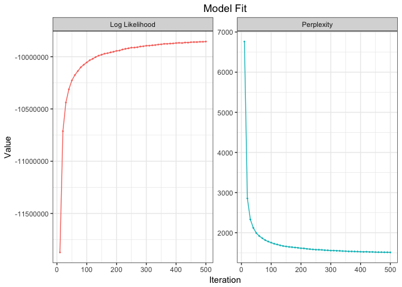

```r
diagnosis_model_fit(post, start=2)
```

### With eight keywords

```r
model <- create_model(docs, lapply(seed_list, use_part_of_seed, use=1:8), extra_k=64)
res <- topicdict_train(model, iter = iter_num)
post <- topicdict::posterior(res)
top_terms(post)
```

```
      1          2          3          4            5
 [1,] "整備 [✓]" "経済 [✓]" "社会 [✓]" "政治 [3]"   "充実 [✓]"
 [2,] "推進"     "社会 [3]" "平和 [✓]" "国民 [✓]"   "企業 [✓]"
 [3,] "道路"     "日本 [4]" "政治 [✓]" "消費 [✓]"   "教育 [✓]"
 [4,] "振興"     "国民 [4]" "日本 [4]" "税 [✓]"     "中小 [✓]"
 [5,] "道"       "改革"     "主義 [✓]" "日本 [✓]"   "福祉 [✓]"
 [6,] "促進"     "世界"     "世界"     "守る"       "図る [1]"
 [7,] "産業 [✓]" "国"       "自由 [✓]" "党"         "社会 [3]"
 [8,] "地域"     "必要"     "実現 [✓]" "全力"       "進める [✓]"
 [9,] "開発 [✓]" "国際"     "国民 [4]" "進める [5]" "対策"
[10,] "図る [✓]" "景気"     "民主 [✓]" "廃止 [✓]"   "実現 [3]"
      T_1          T_2        T_3        T_4      T_5        T_6
 [1,] "党"         "市民"     "農業 [1]" "事業"   "支援"     "憲法"
 [2,] "共産"       "社会 [3]" "自給"     "国"     "企業 [5]" "税 [4]"
 [3,] "費"         "民主 [3]" "食糧"     "財政"   "制度"     "消費 [4]"
```

[output cut: 128 more lines]

```r
tail(post$alpha,1)
```

```
    EstTopic1 EstTopic2 EstTopic3 EstTopic4 EstTopic5  EstTopic6
500 0.1835471  0.222505 0.1939739 0.2357703 0.2943209 0.03746828
     EstTopic7 EstTopic8  EstTopic9 EstTopic10 EstTopic11 EstTopic12
500 0.03661458 0.1144701 0.02487248 0.06550967 0.03486031 0.04303621
    EstTopic13 EstTopic14 EstTopic15 EstTopic16 EstTopic17 EstTopic18
500   0.120255  0.1211367 0.01311092 0.03915162 0.02891878 0.02043259
    EstTopic19 EstTopic20 EstTopic21 EstTopic22 EstTopic23 EstTopic24
500 0.05924495 0.02956485  0.0634454 0.01726094  0.0192675 0.05366466
    EstTopic25 EstTopic26 EstTopic27 EstTopic28  EstTopic29 EstTopic30
500  0.1178876 0.07479806 0.03234731 0.06769826 0.009309435 0.02544477
    EstTopic31 EstTopic32 EstTopic33 EstTopic34 EstTopic35 EstTopic36
500 0.06107999 0.04988811  0.1065024 0.03064219 0.07242667 0.03791755
    EstTopic37 EstTopic38 EstTopic39 EstTopic40 EstTopic41 EstTopic42
500  0.1421158 0.05352488   0.078264 0.02873567 0.04282479  0.1392515
    EstTopic43 EstTopic44 EstTopic45 EstTopic46 EstTopic47 EstTopic48
500 0.07204645 0.09861406 0.02070562 0.02710866 0.04092435 0.07248496
    EstTopic49 EstTopic50 EstTopic51 EstTopic52 EstTopic53 EstTopic54
500  0.1149608 0.06573462 0.05572777 0.08320905 0.05271445 0.01279754
    EstTopic55 EstTopic56 EstTopic57 EstTopic58 EstTopic59 EstTopic60
500 0.05656213 0.05725004 0.07872551 0.02266651 0.04944625  0.1507345
    EstTopic61 EstTopic62 EstTopic63 EstTopic64 EstTopic65 EstTopic66
500  0.1366217 0.02594584 0.03391821 0.06573953 0.07503246 0.01778488
    EstTopic67 EstTopic68 EstTopic69 iter
500 0.04514944 0.05535179 0.05938955  500
```

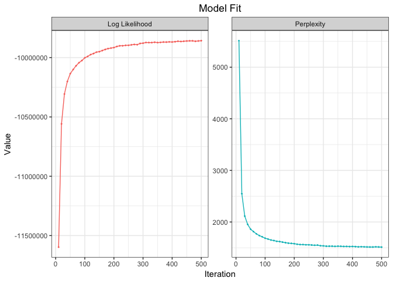

```r
diagnosis_model_fit(post, start=2)
```

## Other number

### 15

```r
model <- create_model(docs, lapply(seed_list, use_part_of_seed, use=1:8), extra_k=10)
res <- topicdict_train(model, iter = iter_num)
post <- topicdict::posterior(res)
top_terms(post)
```

```
      1          2          3          4            5
 [1,] "整備 [✓]" "日本 [4]" "政治 [✓]" "党"         "円"
 [2,] "政治 [3]" "社会 [3]" "社会 [✓]" "日本 [✓]"   "教育 [✓]"
 [3,] "図る [✓]" "改革"     "実現 [✓]" "共産"       "守る"
 [4,] "推進"     "経済 [✓]" "平和 [✓]" "国民 [✓]"   "減税"
 [5,] "振興"     "国"       "生活"     "政治 [3]"   "平和 [3]"
 [6,] "実現 [3]" "世界"     "守る"     "税 [✓]"     "費"
 [7,] "地域"     "政策"     "目指す"   "消費 [✓]"   "反対"
 [8,] "産業 [✓]" "国際"     "環境"     "自民党 [✓]" "企業 [✓]"
 [9,] "福祉 [5]" "国民 [4]" "国民 [4]" "増税"       "福祉 [✓]"
[10,] "充実 [5]" "問題"     "民主 [✓]" "企業 [5]"   "自民党 [4]"
      T_1          T_2        T_3          T_4        T_5        T_6
 [1,] "政治 [3]"   "円"       "増税"       "改革"     "社会 [3]" "選挙"
 [2,] "改革"       "年金"     "党"         "地方"     "作り"     "ひと"
 [3,] "自民党 [4]" "政権"     "憲法"       "行政"     "日本 [4]" "議員"
```

[output cut: 18 more lines]

```r
tail(post$alpha,1)
```

```
    EstTopic1 EstTopic2 EstTopic3 EstTopic4  EstTopic5 EstTopic6 EstTopic7
500 0.2769552 0.3373779 0.3008914 0.1277211 0.09326321 0.1228175 0.0910357
     EstTopic8 EstTopic9 EstTopic10 EstTopic11 EstTopic12 EstTopic13
500 0.07242774  0.151699  0.2834914  0.2478373 0.06933134 0.09133028
    EstTopic14 EstTopic15 iter
500  0.2009128  0.1878822  500
```

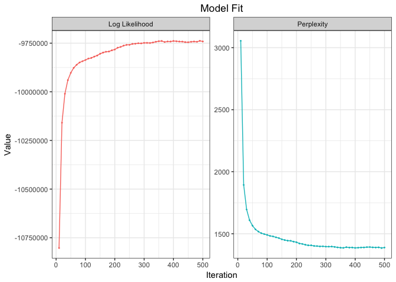

```r
diagnosis_model_fit(post, start=2)
```

### 20

```r
model <- create_model(docs, lapply(seed_list, use_part_of_seed, use=1:8), extra_k=15)
res <- topicdict_train(model, iter = iter_num)
post <- topicdict::posterior(res)
top_terms(post)
```

```
      1          2          3          4          5
 [1,] "整備 [✓]" "改革"     "社会 [✓]" "日本 [✓]" "教育 [✓]"
 [2,] "道路"     "社会 [3]" "政治 [✓]" "党"       "進める [✓]"
 [3,] "実現 [3]" "日本 [4]" "平和 [✓]" "共産"     "図る [1]"
 [4,] "推進"     "経済 [✓]" "環境"     "国民 [✓]" "企業 [✓]"
 [5,] "振興"     "地方"     "実現 [✓]" "政治 [3]" "充実 [✓]"
 [6,] "産業 [✓]" "地域"     "自由 [✓]" "税 [✓]"   "社会 [3]"
 [7,] "地域"     "推進"     "民主 [✓]" "消費 [✓]" "福祉 [✓]"
 [8,] "建設"     "国"       "生活"     "増税"     "制度"
 [9,] "道"       "環境"     "主義 [✓]" "民主 [3]" "中小 [✓]"
[10,] "促進"     "景気"     "世界"     "反対"     "農業 [1]"
      T_1          T_2        T_3        T_4        T_5
 [1,] "政治 [3]"   "憲法"     "税 [4]"   "円"       "党"
 [2,] "改革"       "税 [4]"   "消費 [4]" "国民 [4]" "政治 [3]"
 [3,] "選挙"       "消費 [4]" "廃止 [4]" "医療"     "自民党 [4]"
```

[output cut: 29 more lines]

```r
tail(post$alpha,1)
```

```
    EstTopic1 EstTopic2 EstTopic3 EstTopic4 EstTopic5 EstTopic6  EstTopic7
500 0.2110843 0.2539361 0.2177221 0.1157233 0.3105151 0.1565194 0.03893254
     EstTopic8  EstTopic9 EstTopic10 EstTopic11 EstTopic12 EstTopic13
500 0.08981485 0.01993085 0.04584226 0.04903699 0.08723934  0.2817488
    EstTopic14 EstTopic15 EstTopic16 EstTopic17 EstTopic18 EstTopic19
500 0.04831557  0.2876729  0.1492218  0.2163604 0.02717249 0.04581467
    EstTopic20 iter
500  0.1100606  500
```

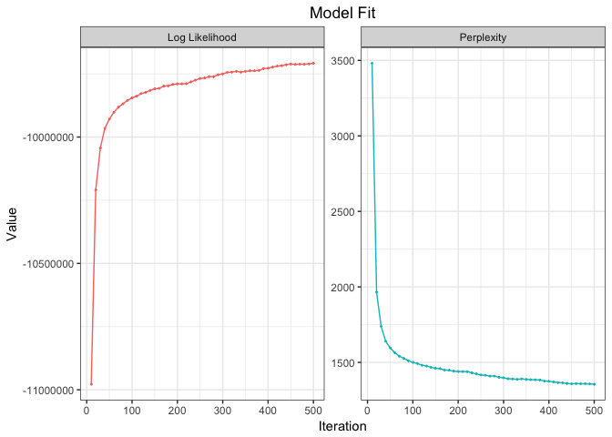

```r
diagnosis_model_fit(post, start=2)
```

### 30

```r
model <- create_model(docs, lapply(seed_list, use_part_of_seed, use=1:8), extra_k=25)
res <- topicdict_train(model, iter = iter_num)
post <- topicdict::posterior(res)
top_terms(post)
```

```
      1          2          3          4            5
 [1,] "整備 [✓]" "改革"     "政治 [✓]" "党"         "企業 [✓]"
 [2,] "産業 [✓]" "社会 [3]" "社会 [✓]" "国民 [✓]"   "図る [1]"
 [3,] "地域"     "日本 [4]" "平和 [✓]" "政治 [3]"   "教育 [✓]"
 [4,] "振興"     "地方"     "実現 [✓]" "日本 [✓]"   "中小 [✓]"
 [5,] "図る [✓]" "経済 [✓]" "国民 [4]" "共産"       "福祉 [✓]"
 [6,] "農業 [✓]" "推進"     "生活"     "自民党 [✓]" "対策"
 [7,] "県"       "国"       "目指す"   "守る"       "充実 [✓]"
 [8,] "農林"     "教育 [5]" "守る"     "企業 [5]"   "進める [✓]"
 [9,] "漁業 [✓]" "制度"     "福祉 [5]" "平和 [3]"   "制度"
[10,] "道"       "実現 [3]" "環境"     "民主 [3]"   "安定"
      T_1        T_2      T_3          T_4        T_5        T_6
 [1,] "日本 [4]" "支援"   "議員"       "日本 [4]" "消費 [4]" "市民"
 [2,] "国"       "安全"   "選挙"       "世界"     "税 [4]"   "社会 [3]"
 [3,] "必要"     "安心"   "院"         "経済 [2]" "憲法"     "環境"
```

[output cut: 51 more lines]

```r
tail(post$alpha,1)
```

```
    EstTopic1 EstTopic2 EstTopic3 EstTopic4 EstTopic5 EstTopic6 EstTopic7
500 0.2194203 0.2166213 0.2999878 0.1052268 0.2676702 0.1351085 0.1013727
    EstTopic8 EstTopic9 EstTopic10 EstTopic11 EstTopic12 EstTopic13
500 0.1202017 0.2024547 0.03452381 0.09300381  0.1901192 0.01459561
    EstTopic14 EstTopic15 EstTopic16 EstTopic17 EstTopic18 EstTopic19
500 0.03621843 0.04818475 0.04175168 0.03774605 0.03956828  0.2145005
    EstTopic20 EstTopic21 EstTopic22 EstTopic23 EstTopic24 EstTopic25
500  0.0645794  0.1256174  0.1006244  0.2287947 0.04650548  0.0332441
    EstTopic26 EstTopic27 EstTopic28 EstTopic29 EstTopic30 iter
500 0.02891336  0.1798301 0.05889666  0.0781519 0.06204053  500
```

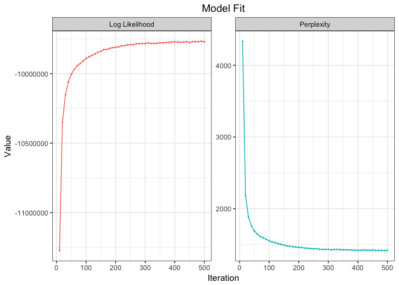

```r
diagnosis_model_fit(post, start=2)
```